# OLA Driver Churn Prediction

- Male churn rate: $~67.5$%
- Female churn rate: $~68.4$%

  ✅ Interpretation
  - Churn rate is almost the same for both genders.
  - Gender does NOT influence churn.

**🎓 2. Education Level vs Churn**

- Secondary School: $69.1$% churn
- Higher Secondary: $66.3$% churn
- Graduate: $68.2$% churn

  ✅ Interpretation
  - Churn rates across education levels are very similar.
  - No strong pattern that education influences churn.

**🎯 3. Grade vs Churn**

- Grade 1: $80.4$% churn (very high)
- Grade 2: $70.2$% churn
- Grade 3: $54.1$% churn
- Grade 4: $50.7$% churn
- Grade 5: $54.2$% churn

  ✅ Interpretation
  - Low-grade drivers churn the most.
  - Grade 1 has the highest churn ($80.4$%).
  - Churn decreases as grade improves (up to 4).
  - Grade seems to reflect driver performance level.

**💰4. Income Change vs Churn**

- Income not increased: $69$% churn
- Income increased: only $7$% churn

  ✅ Interpretation
  - Drivers whose income increased are very unlikely to churn.
  - Drivers whose income did not increase churn massively.

**⭐ 5. Quarterly Rating Increase vs Churn**

- Rating Not increased: $75.8$% churn
- Rating Increased: $22.9$% churn

  *🔥Very strong insight*
  - Drivers whose quarterly ratings improve stay.
  - Drivers with stagnant ratings leave.

  ✅ Interpretation
  - Rating improvement reflects driver satisfaction, performance, and stability.
  - Very strong predictor.

**🏢 6. Joining Designation vs Churn**

- Lower designations (1, 2): ~$70$% churn
- Mid designation (3): $55.6$% churn
- Higher designation (4): $61.1$% churn
- Highest (5): $72.7$% churn

  ✅ Interpretation
  - Mid-tier drivers (Designation 3 & 4) churn less.
  - Very junior & very senior churn more. Why?
  - Juniors: less experience → unstable income
  - Seniors: possible dissatisfaction or performance drop

**👶🧓 7. Age Group vs Churn**

- Youngsters: $71.2$% churn
- Middle-aged: $66.6$% churn
- Elders: $61.5$% churn

  ✅ Interpretation
  - Younger drivers churn the most.
  - Older drivers churn less—likely due to:
    - More stability
    - More experience
    - More responsibility or need for income stability

**Summary**

- The following features have higher contribution for the churn:
  - Income Change → huge difference ($7$% vs $69$%)
  - Quarterly Rating Increased → huge difference ($23$% vs $76$%)
  - Grade → big spread ($50–80$%)
  - Joining Designation → moderate
  - Age group → moderate

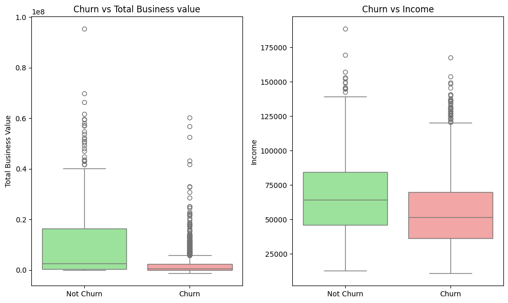

```python
custom_colors = {'0': "#90EE90", '1': "#FF9999"}

plt.figure(figsize=(10,6))

plt.subplot(1, 2, 1)
sns.boxplot(data=df1, x='target', y='Total Business Value', palette=custom_colors)
plt.xlabel(None)
plt.title("Churn vs Total Business value")
plt.xticks([0, 1], ['Not Churn', 'Churn'])

plt.subplot(1, 2, 2)
sns.boxplot(data=df1, x='target', y='Income', palette=custom_colors)
plt.xlabel(None)
plt.title("Churn vs Income")
plt.xticks([0, 1], ['Not Churn', 'Churn'])

plt.tight_layout()
plt.show()
```

```python
def annotate_box_and_summary(ax, data, x_col, y_col, title):
    unique_x = sorted(data[x_col].unique())
    summary_lines = []  # for building the text box content

    for x_val in unique_x:
        subset = data[data[x_col] == x_val][y_col]

        mean_val = subset.mean()
        q1 = subset.quantile(0.25)
        q3 = subset.quantile(0.75)

        x_pos = unique_x.index(x_val)

        # Annotate values on top of the boxplot
        ax.text(x_pos, mean_val, f"Mean: {mean_val:,.0f}",
                ha='center', va='bottom', fontsize=9, color='blue')
        ax.text(x_pos, q1, f"Q1: {q1:,.0f}",
                ha='center', va='bottom', fontsize=9, color='purple')
        ax.text(x_pos, q3, f"Q3: {q3:,.0f}",
                ha='center', va='bottom', fontsize=9, color='brown')

        # Build summary lines
        category_name = "Not Churn" if x_val == 0 else "Churn"
        summary_lines.append(
            f"{category_name}:\n"
            f" • Mean = {mean_val:,.0f}\n"
            f" • Q1 (25%) = {q1:,.0f}\n"
            f" • Q3 (75%) = {q3:,.0f}\n"
        )

    # Add the summary text box to the right side
    text_box = "\n".join(summary_lines)
    ax.text(
        1.15, 0.5, text_box,
        transform=ax.transAxes,
        fontsize=10,
        verticalalignment='center',
        bbox=dict(facecolor='white', edgecolor='black', alpha=0.8)
    )

    ax.set_title(title)
    ax.set_xlabel("")
    ax.set_ylabel("")
```

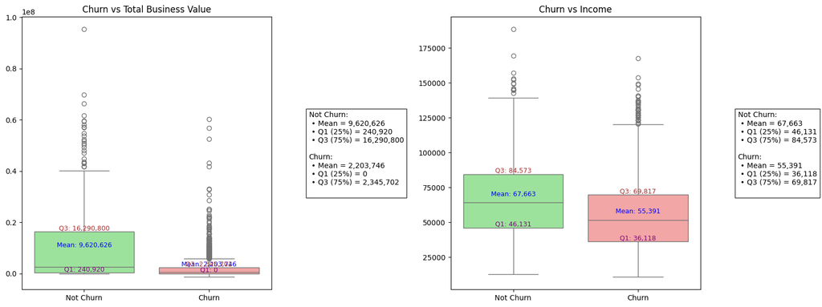

```python
plt.figure(figsize=(16,6))


plt.subplot(1, 2, 1)
ax1 = sns.boxplot(
    data=df1, x='target', y='Total Business Value', palette=custom_colors
)
plt.xticks([0, 1], ['Not Churn', 'Churn'])
annotate_box_and_summary(ax1, df1, 'target', 'Total Business Value',
                         "Churn vs Total Business Value")


plt.subplot(1, 2, 2)
ax2 = sns.boxplot(
    data=df1, x='target', y='Income', palette=custom_colors
)
plt.xticks([0, 1], ['Not Churn', 'Churn'])
annotate_box_and_summary(ax2, df1, 'target', 'Income',
                         "Churn vs Income")

plt.tight_layout()
plt.show()
```

**🟢Not Churned Drivers**

- Higher Income
- Higher Business Value
- Larger upper quartile spread → some top-performing drivers contribute heavily
- They form the financial backbone of the platform

**🔴Churned Drivers**

- Significantly lower income
- Very low business value
- Q1 is nearly zero for business value → majority low performers
- Fewer high-value outliers → fewer loyal or high-earning drivers in this segment

Low performance → Low income → High churn

High performance → High income → Low churn